# EMPRÉSTIMOS FINANCIADOS PELA PROSPER

Márcio Ozório de Jesus

E-mail: marcio.ozorio@gmail.com  
LinkedIn: https://www.linkedin.com/in/marciojesus/

# A. INTRODUÇÃO

# B. INFORMAÇÕES DA BASE DE DADOS

# C. QUESTÕES A SEREM EXPLORADAS

# D. ANÁLISES

## D.I. DISTRIBUIÇÕES E ESTATÍSTICAS GERAIS

## D.II. VALOR DA RENDA

## D.III. VALOR DO EMPÉSTIMO / QUANTIDADE DE PARCELAS

## D.IV. TAXA DE JUROS

# E. CORRELAÇÕES

# F. GRÁFICO FINAIS E RESUMO

# G. REFLEXÃO

# H. REFERÊNCIAS

# A. INTRODUÇÃO

Este estudo faz parte do curso de Análise de Dados da [Udacity](http://udacity.com) onde será utilizada a base de dados da empresa de [Prosper](https://www.prosper.com). A Prosper foi fundada em 2005 e foi a primeira plataforma de serviço de empréstimos ponto a ponto (peer-to-peer) dos Estados Unidos com mais de US $ 7 bilhões em empréstimos financiados.

Os mutuários (recebedores do empréstimo) solicitam empréstimos através da Prosper e os investidores (pessoas Físicas ou Jurídicas) podem financiar quantias entre US $ 1.000 a US $ 35.000.

Os mutuários fazem a solicitações de empréstimo, a Prosper verifica a identidade, seleciona dados pessoais e executa um algoritimo que analisa o risco de crédito e retorna a taxa a ser utilizada. Os investidores analisam o relatório de crédito do mutuário com a taxa de juros calculada pela Prosper e decidem se irão ou não conceder o empréstimo. A Prosper lida com o serviço de coleta e distribui o pagamento de mutuários juntamente com os juros de volta aos investidores dos empréstimos, gerenciando todas as etapas do processo. A Prosper gera receita cobrando uma taxa sobre os empréstimos financiados.

Obs.: Irei trabalhar com a lingua padrão da base de dados que é a lingua inglesa e adicionarei comentários em português.

# B. INFORMAÇÕES DA BASE DE DADOS

Temos um total 81 colunas ou variáveis e 113.937 observações (registros).

Você pode baixar a base de dados através do link abaixo: https://www.kaggle.com/jschnessl/prosperloans/data

Abaixo segue o nome de todas as colunas de nossa base:

```
##  [1] "ListingKey"
##  [2] "ListingNumber"
##  [3] "ListingCreationDate"
##  [4] "CreditGrade"
##  [5] "Term"
##  [6] "LoanStatus"
##  [7] "ClosedDate"
##  [8] "BorrowerAPR"
##  [9] "BorrowerRate"
## [10] "LenderYield"
## [11] "EstimatedEffectiveYield"
## [12] "EstimatedLoss"
## [13] "EstimatedReturn"
## [14] "ProsperRating..numeric."
## [15] "ProsperRating..Alpha."
```

[output cut: 66 more lines]

Dicionário de dados com maiores detalhes: https://docs.google.com/spreadsheets/d/1gDyi_L4UvIrLTEC6Wri5nbaMmkGmLQBk-Yx3z0XDEtI/edit#gid=0

Analisando as colunas de nossa base de dados, encontrou-se duas variáveis com valores nulos. As quantidades estão indicadas abaixo (de um total de 113.932). Apesar disso, os valores nulos não irão afetar a nossa Análise.

```
##   isnull                variable
## 4  29062            ProsperScore
## 7   7522 AvailableBankcardCredit
```

Conforme as instruções da Udacity, iremos selecionar entre 10 a 15 variáveis para este estudo. O processo de Análise das informações mais relevantes resultou no seguinte mapa mental contendo colunas já existentes, novas colunas que serão criadas e a Taxa de Juros que esta destacada na cor verde, pois terá um papel importante em nossa Análise.

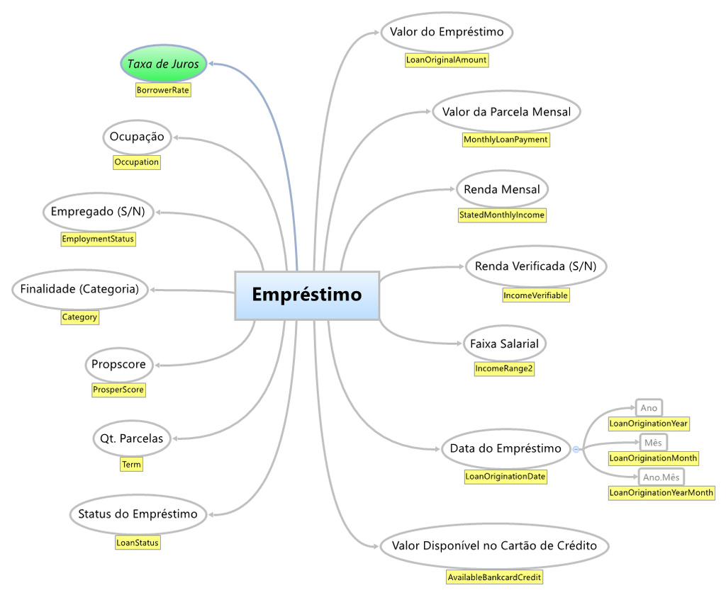

Portanto, foi selecionado 13 colunas da nossa base de dados. E com base nestas informações foram adicionados mais 4 variáveis.

Segue uma tabela com todas as vaiáveis que iremos trabalhar:

| Variáveis | Descrição |
| --- | --- |
| Term | O prazo do empréstimo expresso em meses. |
| LoanStatus | O status atual do empréstimo: cancelado, carregado, concluído, atual, inadimplente, pagamento final em progresso, Vencido. O status Vencido será acompanhado por uma faixa de inadimplência. |
| BorrowerRate | A taxa de juros do mutuário para este empréstimo. |
| ProsperScore | Uma pontuação de risco personalizada construída usando dados históricos Prosper. A pontuação varia de 1-10, sendo 10 o melhor, ou menor pontuação de risco. Aplicável para empréstimos originados após j… |
| Occupation | A Ocupação selecionada pelo mutuário no momento em que eles criaram a listagem. |
| Category | 0 - Nao disponível, 1 - Dívida, 2 - Melhoria domiciliar, 3 - Negócios, 4 - Empréstimo pessoal, 5 - Uso do aluno, 6 - Auto, 7- Outro 8 - Bebê e Adopção, 9 - Barco, 10 - Procedimento Cosmético, 11 - Ane… |
| EmploymentStatus | O status de emprego do mutuário no momento em que publicaram a listagem. |
| AvailableBankcardCredit | O crédito total disponível via cartão bancário no momento em que o perfil de crédito foi puxado. |
| IncomeVerifiable | O mutuário indicou que eles têm a documentação necessária para suportar sua renda. |
| StatedMonthlyIncome | A renda mensal que o mutuário declarou no momento em que a lista foi criada. |
| LoanOriginalAmount | O montante original do empréstimo. |
| LoanOriginationDate | A data em que o empréstimo foi originado. |
| MonthlyLoanPayment | O pagamento mensal programado do empréstimo. |
| LoanOriginationYear | Ano da data em que o empréstimo foi originado. |
| LoanOriginationMonth | Mês da data em que o empréstimo foi originado. |
| LoanOriginationYearMonth | Ano e mês da data em que o empréstimo foi originado (separdo por ponto). |
| IncomeRange | A faixa salarial do mutuário no momento em que a lista foi criada. |

# C. QUESTÕES A SEREM EXPLORADAS

Com base nas variáveis selecionadas, seguem abaixo algumas perguntas que iremos tentar responder:

1. Qual é o maior motivo para a realização de empréstimos?
2. A taxa de juros sofre alguma variação de acordo com a finalidade (categoria) do empréstimo?
3. Quem tem uma renda maior, paga uma parcela maior?
4. Quem tem uma renda maior, faz empréstimos mais altos?
5. Mutuários que estão desempregados tem taxa de juros maiores que as que estão empregadas?
6. Mutuários que estão empregados e que também comprovaram renda, tem juros menor que as que estão empregadas mas não comprovaram renda?
7. Com base nas informações e histórico, a Prosper apura uma pontuação chamada ProsperScore para os mutuarios, onde quanto maior a pontuação, maior a chance de ser um bom pagador (Consequentemente menor risco para o investidor). Esse score realmente tem relação com uma maior ou menor taxa de juros?
8. A renda da pessoa tem alguma influência sobre a taxa de juros utilizada no empréstimo?

# D. ANÁLISES

## D.I. DISTRIBUIÇÕES E ESTATÍSTICAS GERAIS

Primeiro vamos começar realizando uma Análise das distribuições para termos uma ideia geral da base de dados.

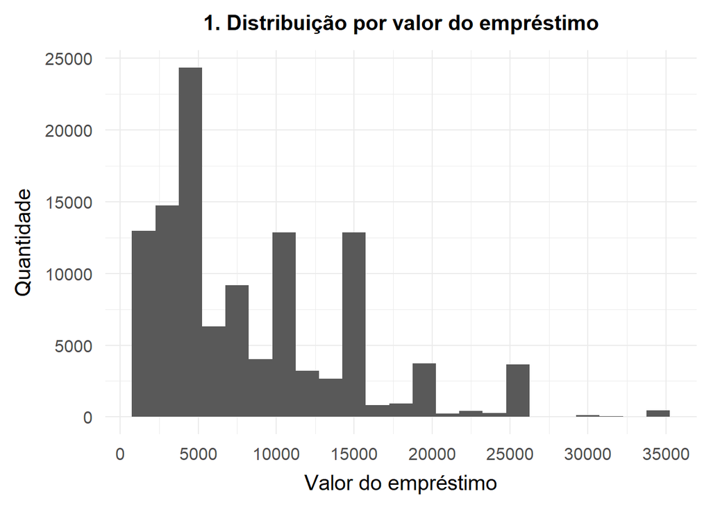

Como podemos ver a distribuição esta com concentração de valores aproximadamente de 1000 a 5000 e depois tem picos a cada 5000, que indica os valores mais comum de empréstimos.

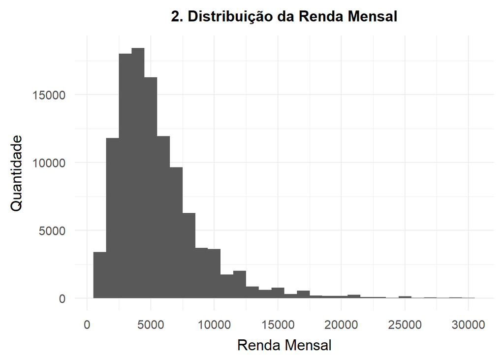

Neste gráfico limitamos os salários até 30000. A maior concentração de salários fica aproximadamente entre 3000 a 5000

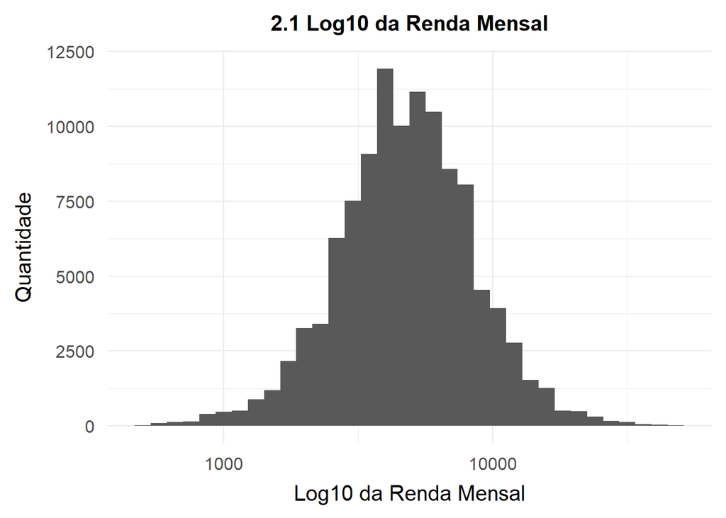

A distribuição da renda mensal é uma distribuição normal. Foi gerada usando uma escala de log10.

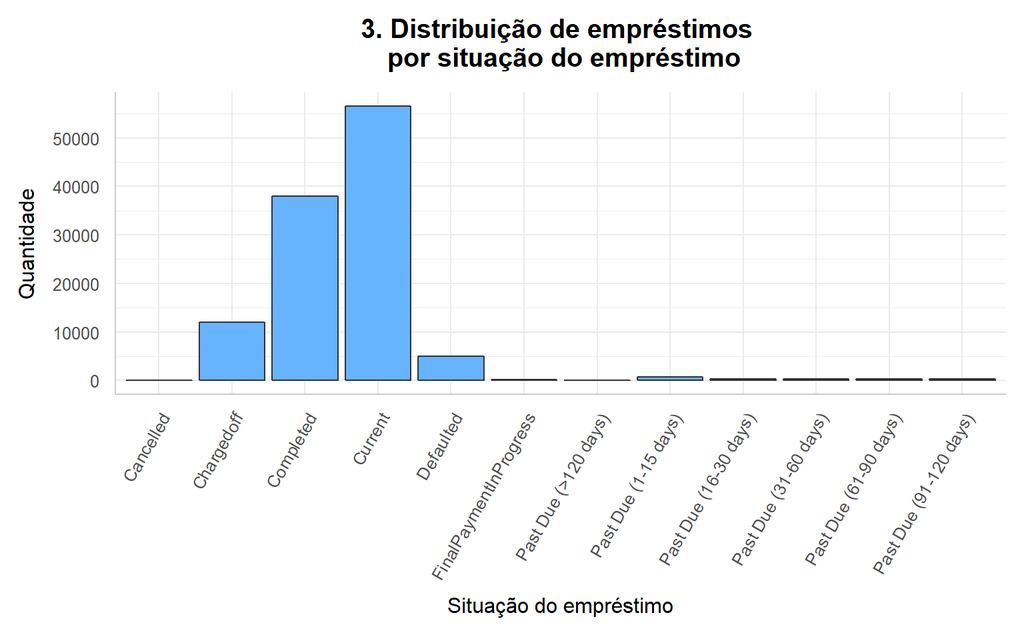

Note acima que a maioria dos empréstimos estão em andamento (Current). Existem uma série de status de empréstimo indicando a quantidade de dias que estão vencidos.

| Tradução |  |
| --- | --- |
| Cancelled | Cancelado |
| Chargedoff | Cobrados fora |
| Completed | Concluído |
| Current | Em andamento |
| Defaulted | Padronizados |
| Final Payment In Progress | Pagamento final em andamento |
| Past Due (>120 days) | Vencido (> 120 dias) |
| Past Due (1-15 days) | Vencido (1-15 dias) |
| Past Due (16-30 days) | Vencido (16 a 30 dias) |
| Past Due (31-60 days) | Vencido (31-60 dias) |
| Past Due (61-90 days) | Vencido (61-90 dias) |
| Past Due (91-120 days) | Vencido (91-120 dias) |

> Iremos desconsidearr as observações com status do empréstimo igual a “Cancelled” (são apenas 5)

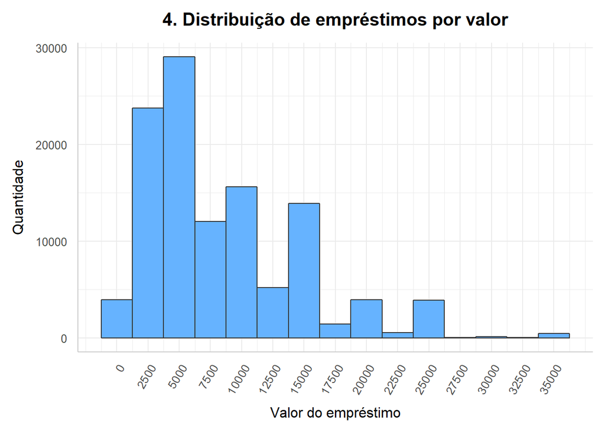

As estatisticas abaixo indicam que a média de valor dos emprestimos é de US$ 8337 e que do total de empéstimos 75% de até US$ 12000.

```
##    Min. 1st Qu.  Median    Mean 3rd Qu.    Max.
##    1000    4000    6500    8338   12000   35000
```

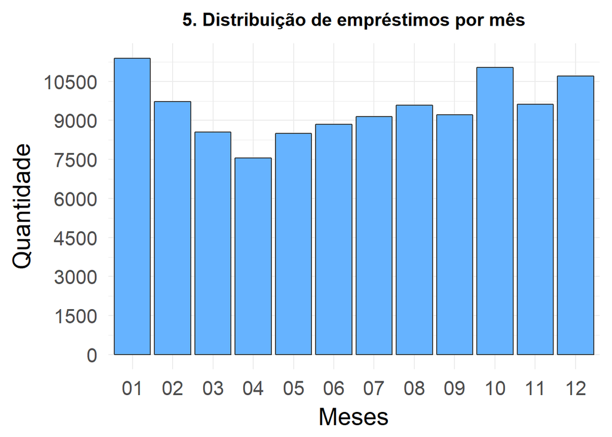

Note que os meses que tiveram maiores quantidades de empréstimos foram os meses do final e inicio do ano e também o mês de outubro.

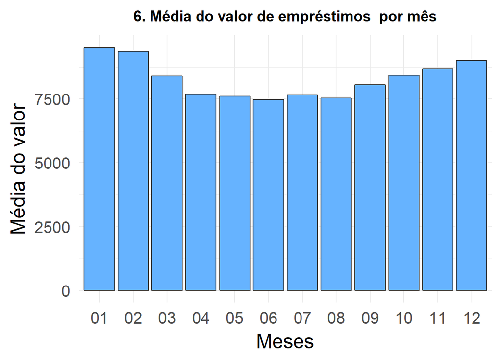

Agora considerando a média de valores emprestados, os meses com maior média foram janeiro, fevereiro seguido de dezembro.

Analisando os valores de empréstimos por mês

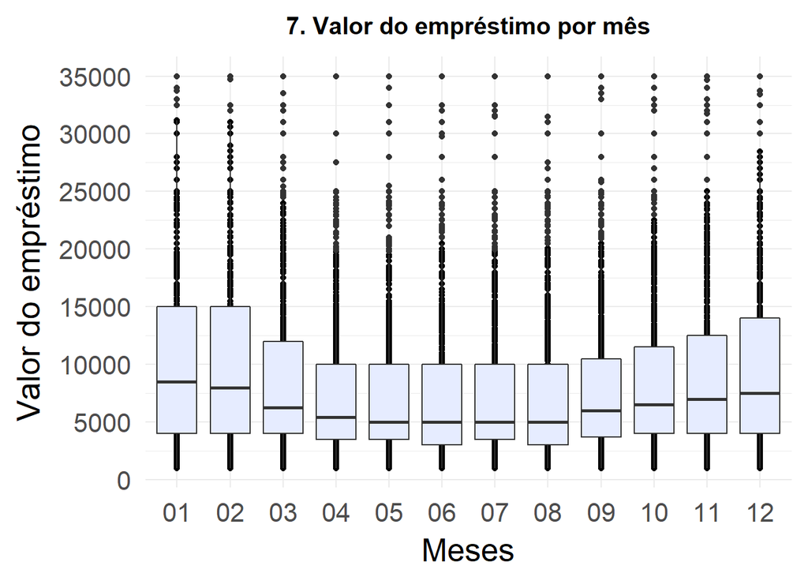

Neste gráfico odemos ver a concentração dos empréstimos de acordo com os valores. O traço na horizontal no meio do retângulo indica a mediana. Os pontos pretos indicam os outliers (exceções).

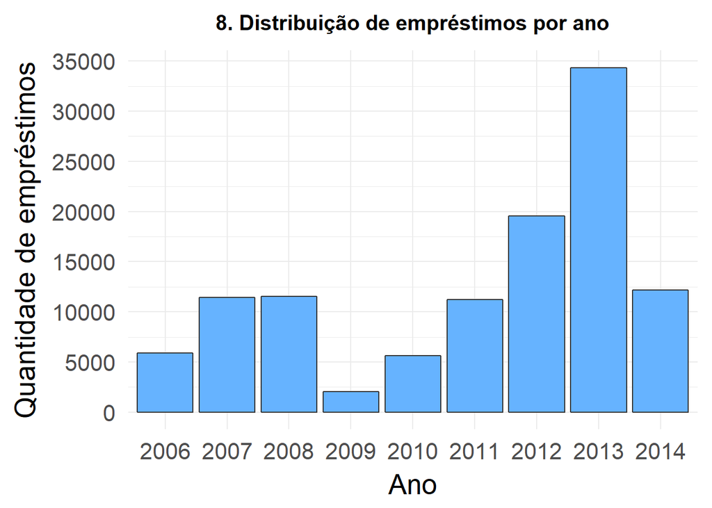

Estamos analisando os dados de 2006 a 2014. Notamos que em 2009 houve uma grande queda. Sabe-se que entre 2007 e 2008 houve uma crise financeira mundial. Talvez isto pode ter alguma relação com a diminuição dos empréstimos nestes anos.

Após 2009 a quantidade de emprestimos tornou a crescer, no entnato, em 2014 o valor volta a cair. Vamos analisar o que pode ter acontecido em 2014:

**Quantidade de empréstimos realizados em 2014 por mês:**

```
## # A tibble: 3 x 2
##   LoanOriginationYearMonth     n
##   <chr>                    <int>
## 1 2014.01                   5865
## 2 2014.02                   4485
## 3 2014.03                   1822
```

Veja que o ano de 2014, tivemos somente três meses registrados com emprestimos, mas apesar disso 2014 tem uma contagem bastante alta, somando 12.172 emprestimos. Vamos continuar a análise.

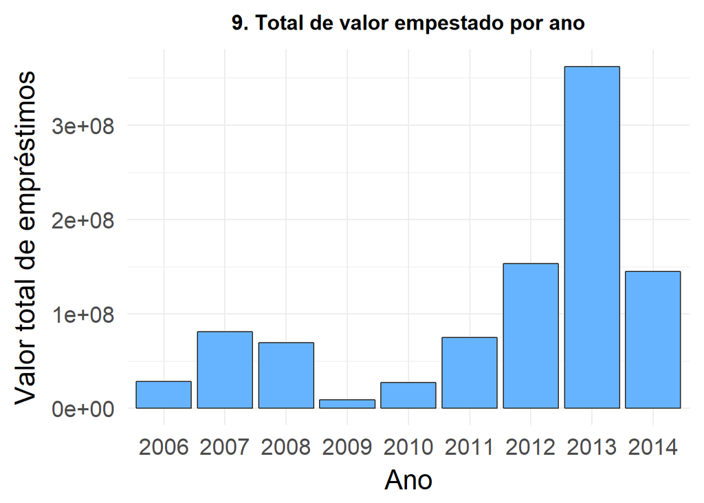

Apesar de 2014 ter somente três meses de empréstimos realizados, em valor ele já tem a mesma quantia que o ano inteiro de 2012. Isso indica que 2014 provavelmente será um ano com a maior número de emprestimos realizados.

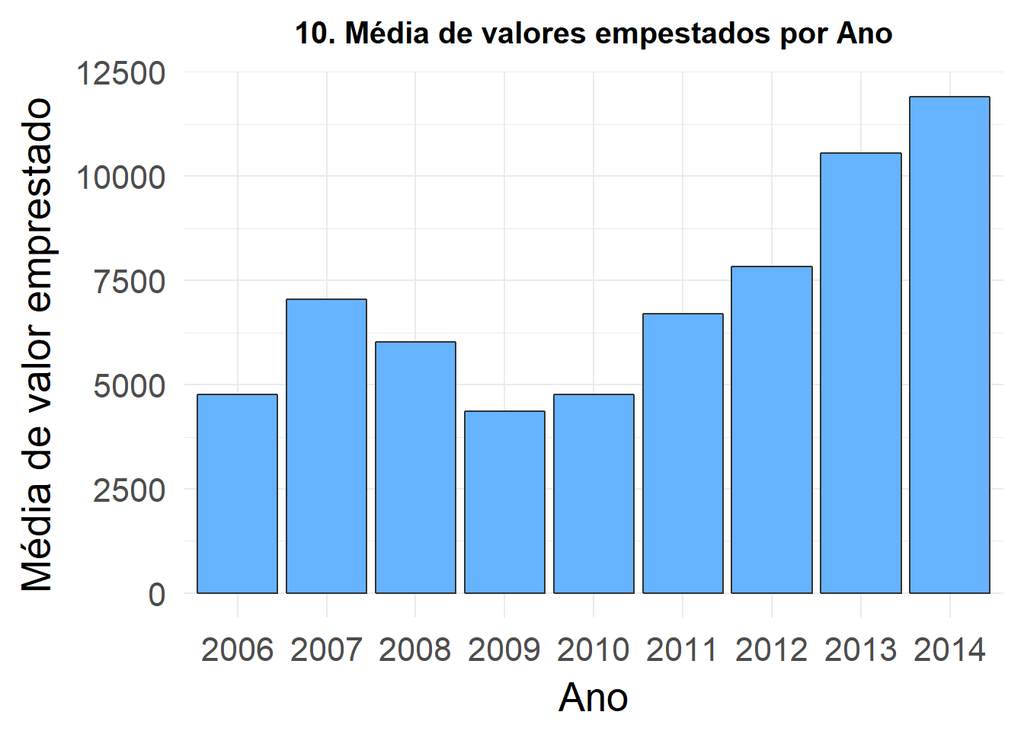

Aqui podemos confirmar uma tendência. Em 2014 houve uma quantidade pequena de empréstimos em relação ao ano de 2013 conforme vimos no gráfico 8, no entanto, a média dos valores emprestados foi a mais alta já registrada. Há que considera ainda que em 2014 temos apenas três meses.

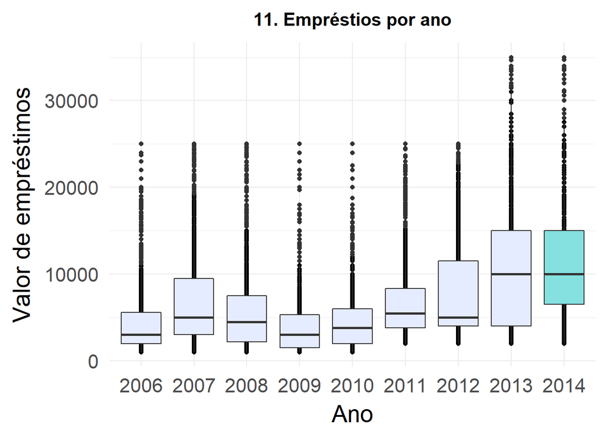

No entanto temos que considerar que em 2014 há somente três meses. Para compararmos com os demais meses e sabermos se realmente pode ser uma tendência iremos calcular abaixo a média somente os três primeiros meses de cada ano:

```
## df_tree_months$LoanOriginationYear: 2006
## [1] 4959.831
## --------------------------------------------------------
## df_tree_months$LoanOriginationYear: 2007
## [1] 6472.595
## --------------------------------------------------------
## df_tree_months$LoanOriginationYear: 2008
## [1] 6658.935
## --------------------------------------------------------
## df_tree_months$LoanOriginationYear: 2010
## [1] 4773.685
## --------------------------------------------------------
## df_tree_months$LoanOriginationYear: 2011
## [1] 6577.909
## --------------------------------------------------------
## df_tree_months$LoanOriginationYear: 2012
## [1] 7455.283
## --------------------------------------------------------
## df_tree_months$LoanOriginationYear: 2013
## [1] 9386.756
## --------------------------------------------------------
## df_tree_months$LoanOriginationYear: 2014
## [1] 11912.22
```

Podemos ver que para o ano de 2014 realmente o valor médio está bem maior que os demais anos, ou seja, há uma grande possibilidade de 2014 ser o ano com maior valor de empréstimos de todos os tempos.

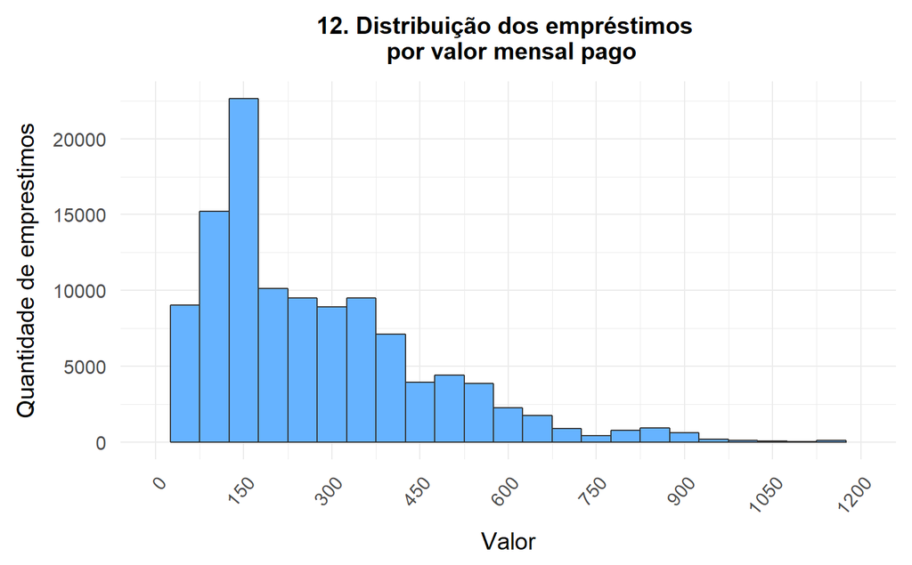

A maioria das parcelas são de aproximadamente US$ 150.

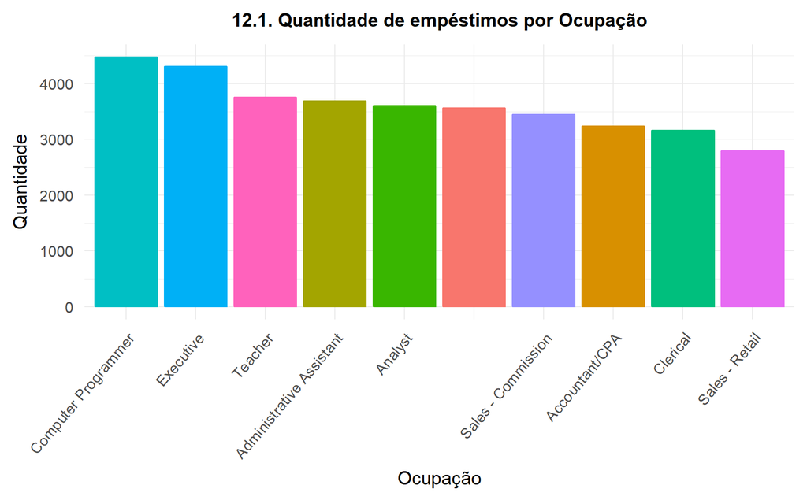

As cinco ocupações que tem o maior número de emprestimos são: Programadores de computador, Executivos e Professores, Assistentes Administrativos e Analistas. Obs.: Foram desconsiderados os casos onde a ocupação é igual a Outros (Others) ou Profissional (Professional)

## D.II. VALOR DA RENDA

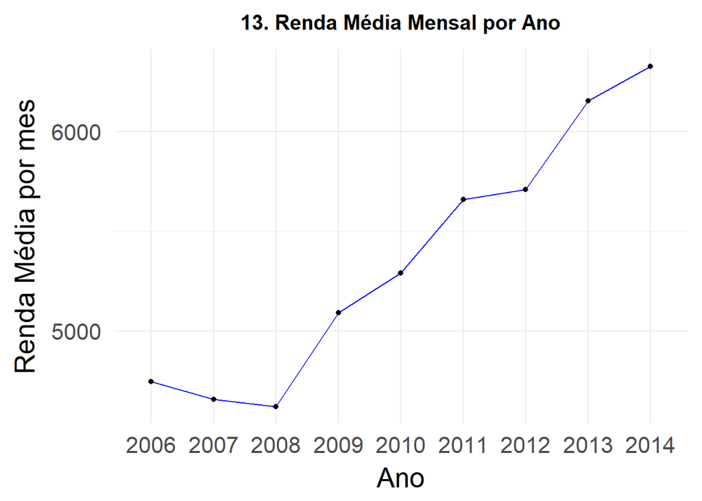

Podemos ver que durante esses 9 anos, a renda média teve variação entre US$ 4500 a US$ 6500.

Vamos analisar a dispersão da renda ao longo dos anos:

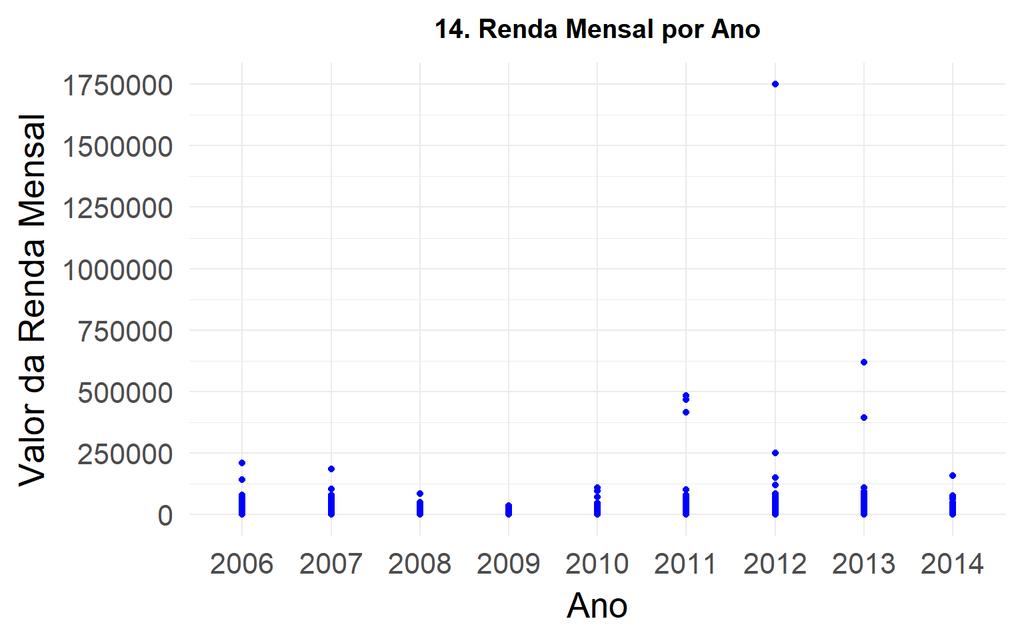

Podemos notar que em 2012 existe um outlier. Analisando os detalhes, foi constatado que este mutuário tem a renda mensal de US$ 1750000, mas nao tem a renda comprovada.

Vamos agora visualizar as informações retirando os outliers, ou seja, vamos filtrar somente os mutuários com renda mensal abaxo de US$ 7500.

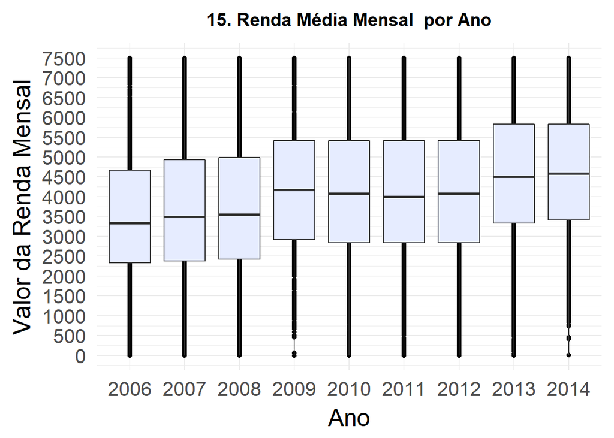

A renda dos mutuários vem tendo um crescimento progressivo no decorrer dos anos

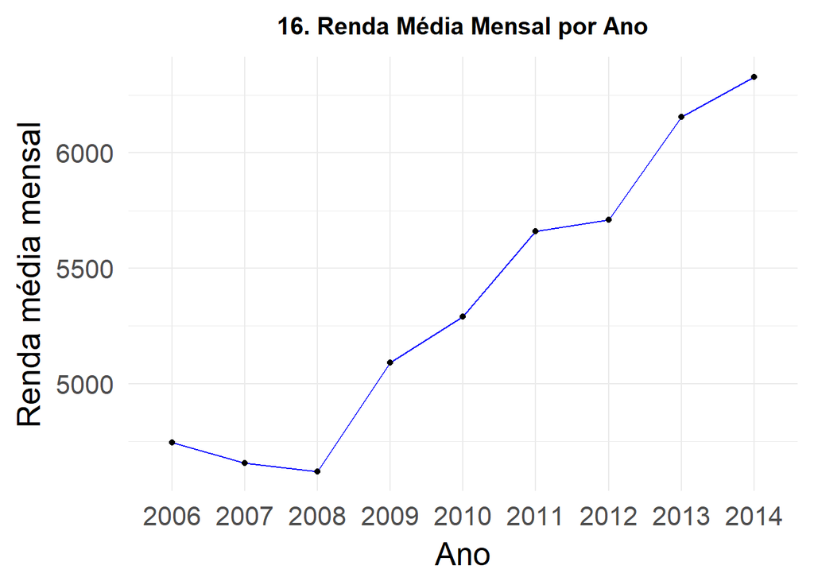

Entre o anos de 2006 a 2008, houve uma ligeira queda. De 2009 em diante, a renda vem aumentando a cada ano.

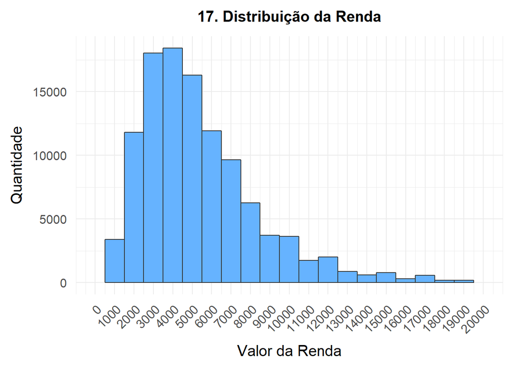

A maioria dos mutuários tem uma renda entre US$ 3000 a US$ 5000 mensais.

Obs.: Foi utilizado um limite para diminuir a calda do gráfico onde esta sendo exibidas somente as rendas mensais de até US$ 20.000.

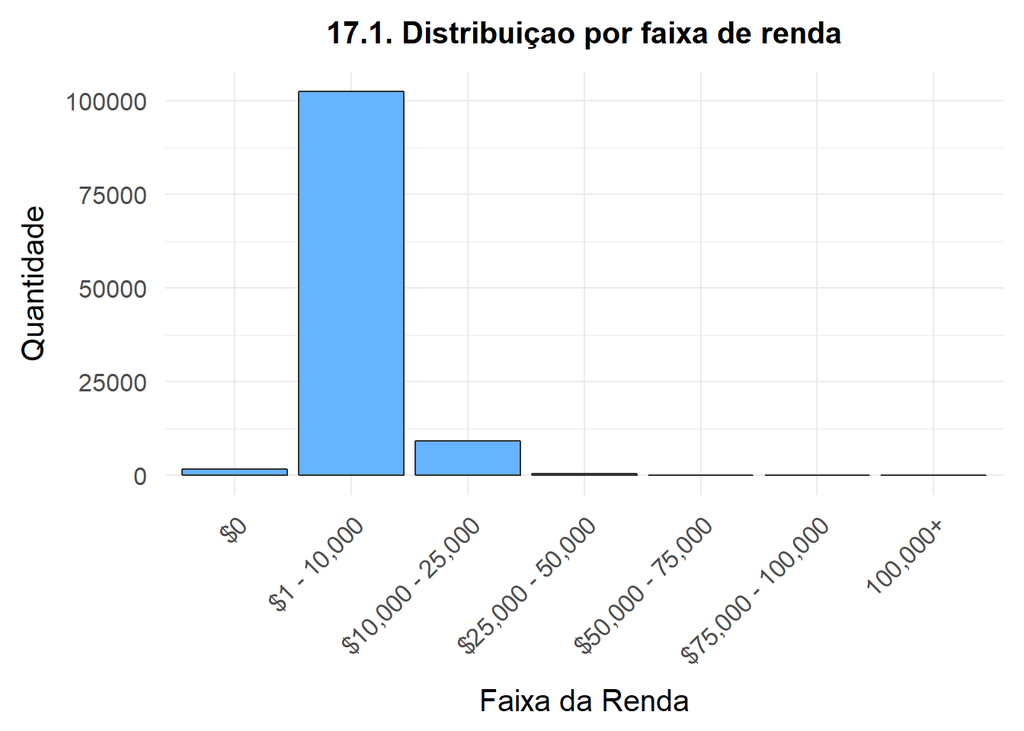

Como verificado no gráfico anterior (17) a maior concentração de renda está entre US$ 3000 e 5000, é obvio que o gráfico acima apresentará ocorrência maior na faixa de renda de US$ 1 a 10000.

## D.III. VALOR DO EMPÉSTIMO / QUANTIDADE DE PARCELAS

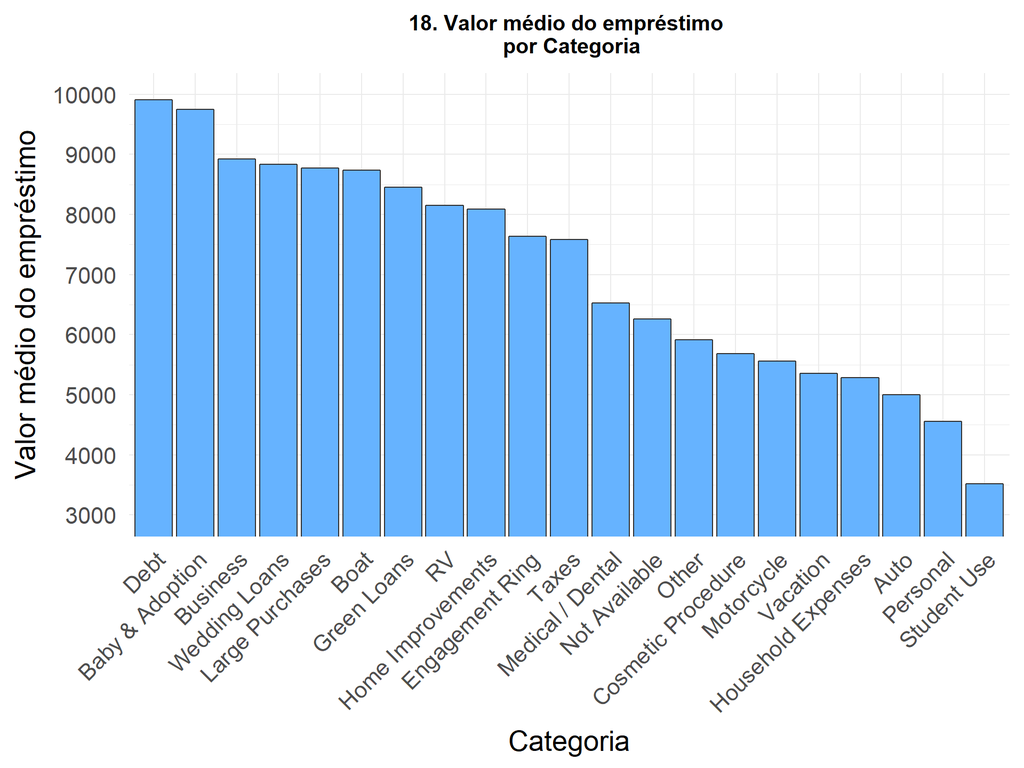

Respondendo à pergunta número 1, neste gráfico é possível identificar que em em média o maior motivo para a realização do empréstimo são para pagamento de Dívidas (Debt). Seguido de Bebê e Adoção (Baby & Adoption), Negócios (Business) e Empréstimos para Casamento (Wedding Loans).

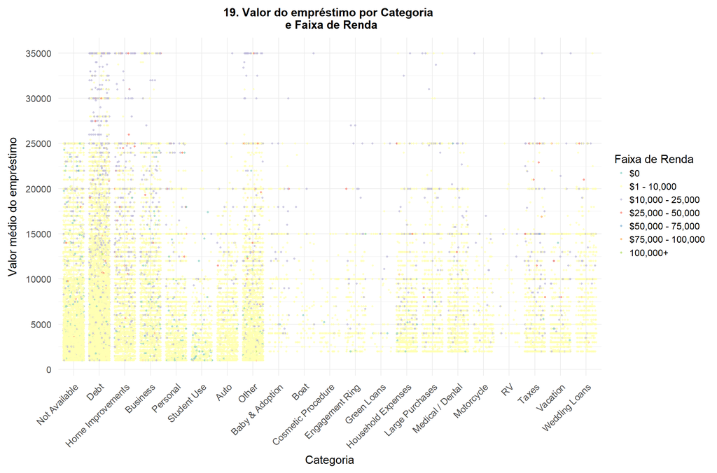

Podemos visualizar a dispersão dos empréstimos visualizando os valores separados por categoria e faixa de renda. Fica claro que maior quantidade de empréstimos é realizada por mutuários com renda entre US$ 1 a 10000. Para empéstimos com valor a partir de US$ 25000, essa faixa quase não tem empéstimos. Provavelmente não são aprovados valores tão altos para esta faixa de renda. Acima de 25000 é mais comum empréstimos para quem tem renda entre US$ 10000 a 25000. A maioria dos empréstimos são utilizados para pagamento de dívidas (debt) As categorias com maiores concentrações de empréstimos são: Dívidas (debt), Outros (Others), Melhorias domiciliares (Home Improvements), Negócios (Business) e não disponível (Not available).

Segue um gráfico de violino com a Distribuição do valor por quantidade de parcelas

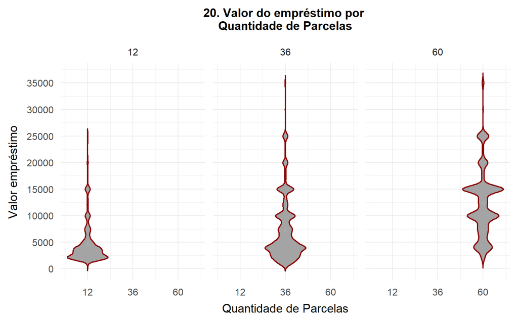

Podemos identificar algumas informações da relação entre o valor do empréstimo e em quantas parcelas eles geralmente são realizados. Note que a maior concentração de empréstimos para 12 parcelas são com valor de até US$ 5000. Para parcelamento em 36 meses, a maioria dos emrpéstimos são de até 10000, com um pequeno pico em 15000. Já para os empréstimos para pagamento em 60 meses, os valores são maiores. Podemos notar que os maiores picos estão em 10000 e 15000.

Em resumo a maioria dos parcelamento realizados em 12 vezes são de valores até US$ 5000, provavelmente para não gerar um empréstimo com valor alto de parcela. Valores baixos a intermediários, são parcelados em 36 vezes. Já para valores médios ou altos, geralmente são parcelados em 60 vezes.

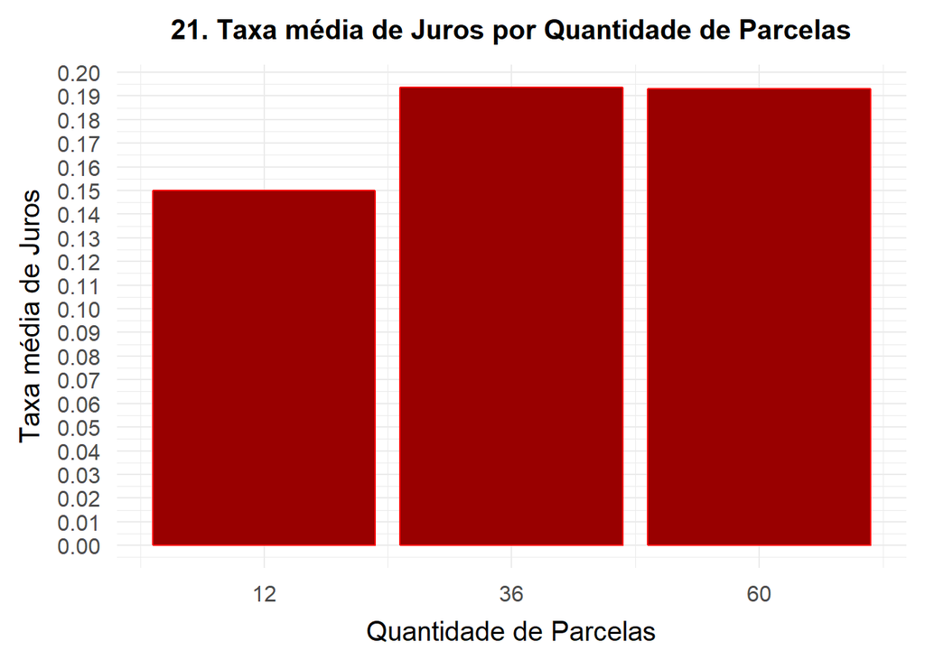

A taxa de juros para quem faz o emprestimo em 12 parcelas é bem menor.

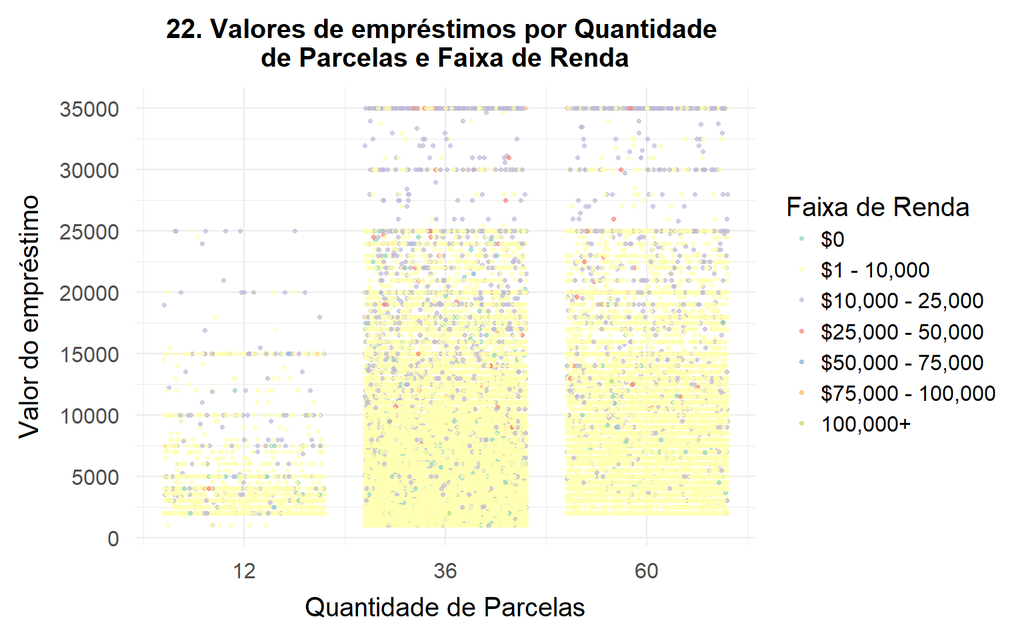

A quantidade de empréstimos para pagamento em 12 meses é bem menor que para 36 e 60 meses. Em todos os casos é nítido que empréstimos com valores maiores, em geral são mais realizados por quem tem a renda mais maior (para empréstimos com pagamento em 12 parcelas - ver ocorrências acima de 15000 e para 36 e 60 meses ver ocorrências acima de 25000).

Considerando que a maioria dos mutuários tem renda entre US$ 1 e 10000, a resposta para a pergunta 4 é sim. Em geral, quem tem maior renda, realiza empréstimos de maior valor.

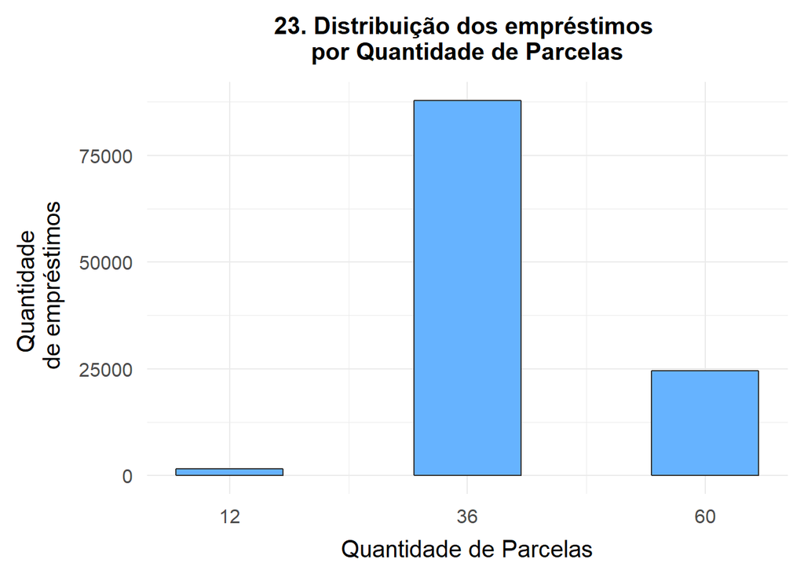

Apensar da opção de parcelamento em 12 vezes ser a opção com a menor taxa de juros, a maioria dos mutuários optam pelo pagamento em 36 meses. Isso se deve provavelmente ao valor da parcela.

Vamos analisar a média de valor por número de parcelas:

```
## df$Term: 12
## [1] 383.9334
## --------------------------------------------------------
## df$Term: 36
## [1] 258.527
## --------------------------------------------------------
## df$Term: 60
## [1] 315.2104
```

Realmente, o menor valor médio de parcelas são para parcelamentos até 36 vezes. E média do valor mensal para empréstimos de 12 vezes é bem maior que para as demais formas de parcelamento.

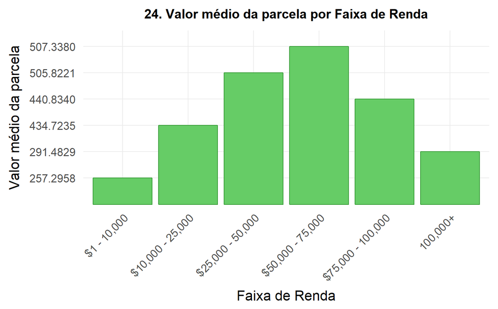

Considerando que o maior número de empréstimos são de mutuários com rendas entre 1 a 10000, podemos responder que sim para a pergunta número 3.

Levando em conta que a maior parte dos empréstimos são realizadas por mutuários com faixa de renda entre 1 a 10000 (conforme gráfico 17.1) e esta faixa de renda tem o valor médio da parcela de aproximadamente US$ 260 conforme o gráfico acima, confirmamos então o que o comentário do gráfico 23 apresenta, onde o parcelamento em 36 vezes é o mais utilizado com uma parcela média aproximada justamente de US$ 260.

## D.IV. TAXA DE JUROS

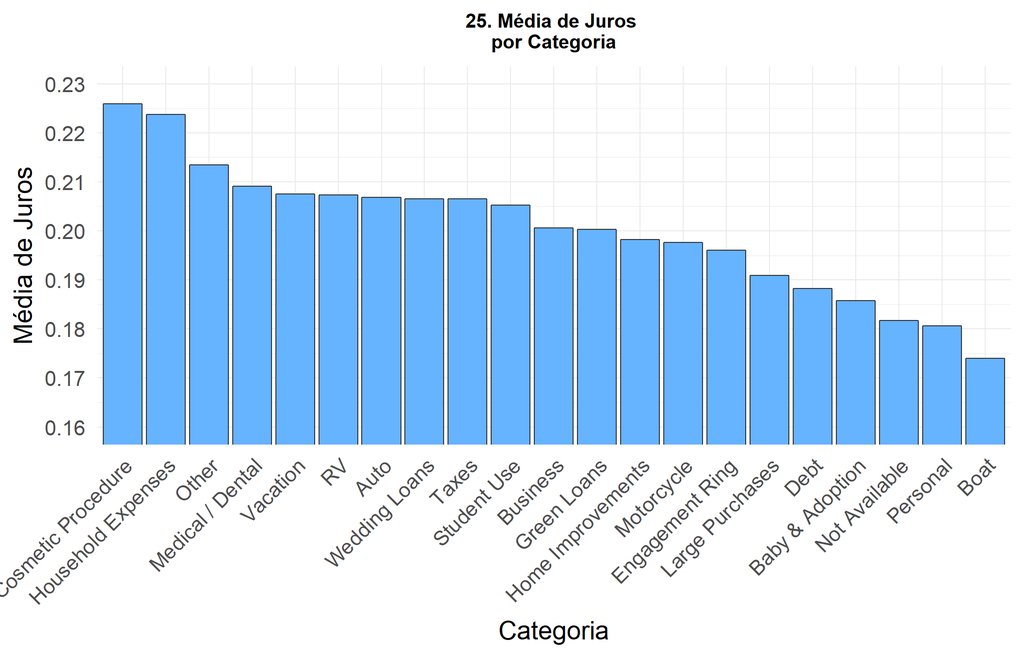

Respondendo a segunda pergunta sim, a taxa de juros também sofre variações de acordo com a categoria do empréstimo. A categorias com maior taxa de juros foi de Procedimentos cosméticos, seguido de Despesas com a Familia e Outros. Já as categorias com menor taxa foram: Barco, Pessoal e a categoria Não disponível.

Vamos ver a variação da taxa de juros ao longo dos anos:

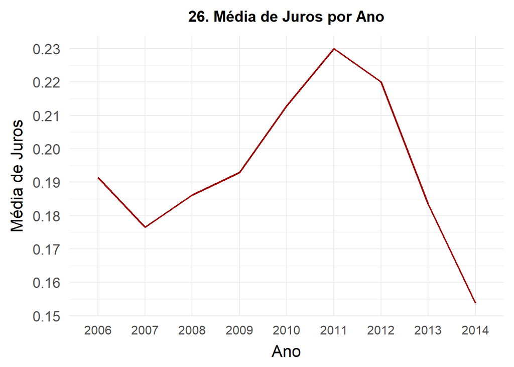

A taxa de juros iniciou em 2006 e caiu em 2007. Após 2007 houveram grandes aumentos até chegar em 2011, onde se deu inicio de quedas sucessivas da taxa de juros até 2014 onde atingiu a taxa de juros mais baixa de todos os anos.

Taxa de juros conforme a renda do mutuário:

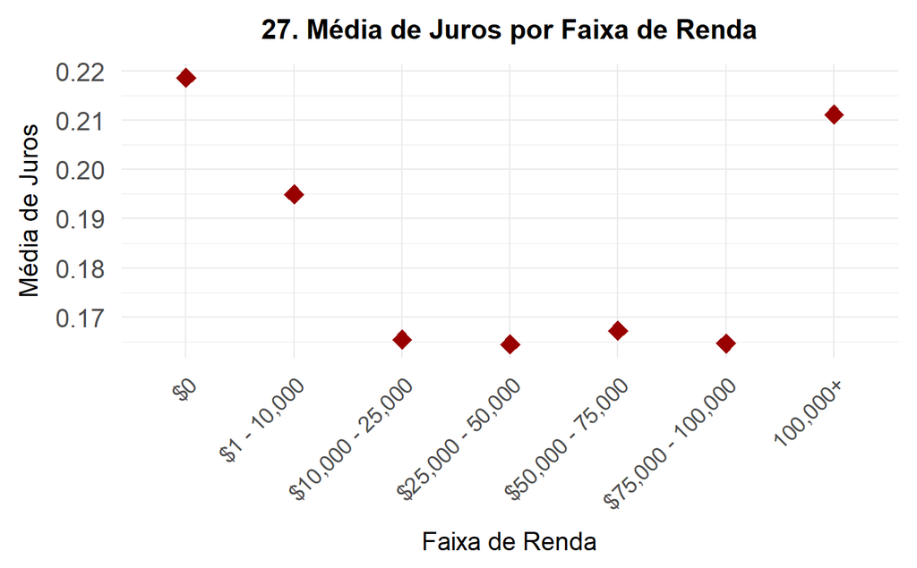

MÉDIA DE JUROS E DE VALOR DE EMPRESTIMOS POR FAIXA DE RENDA AO LONGO DOS ANOS